# Les couleurs

# Introduction

Il y a beaucoup de couleurs disponibles dans R et Python, mais elles ne sont pas toujours facilement visualisables. Beaucoup de couleurs classiques (“gold”, “royalblue”, “lightgreen”, …) et des palettes comme “RdBu” ou “Viridis” se retrouvent a la fois en R et Python, c’est un sujet multilanguage.

On expose ci-dessous une partie des possibilités avec R base et avec quelques packages (liste non exhaustive). Une fois n’est pas coutume, le code n’est pas réalisé avec le package *ggplot2* mais en R base.

# *yellow* et *blue*, pas toujours le meilleur choix

La couleur jaune peut etre difficile a distinguer sur fond blanc, on peut la remplacer par la couleur “or” pour y remedier. Et un texte ecrit en noir sur fond bleu n’est pas plus facile a lire, les couleurs “royalblue” et “cornflowerblue” sont de bonnes alternatives.

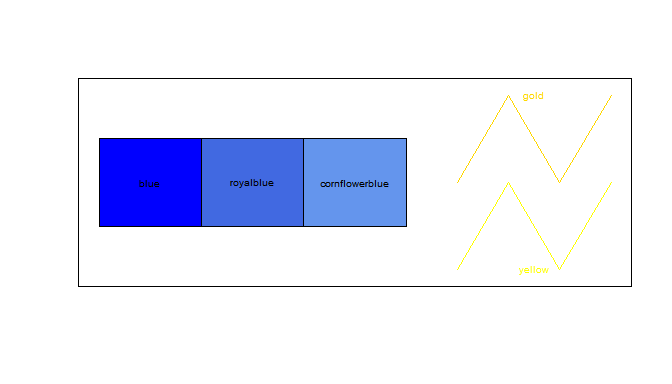

```r
plot(c(0,10), c(0.4,2.6), type = "n", xlab = "", ylab = "", axes = FALSE, frame.plot    = TRUE)
lines(7:10,rep(1:2,2)-0.5,col="yellow");text(x=8.5,y=0.5,labels="yellow",cex=0.6,col="yellow")
lines(7:10,rep(1:2+0.5,2),col= "gold");text(x =8.5,y =2.5, labels= "gold", cex =0.6, col= "gold")
rect(0,1,2,2, col = "blue");text(x = 1, y = 1.5, labels = "blue", cex = 0.6)
rect(2,1,4,2, col = "royalblue");text(x = 3, y = 1.5, labels = "royalblue", cex = 0.6)
rect(4,1,6,2, col = "cornflowerblue");text(x = 5, y = 1.5, labels = "cornflowerblue", cex = 0.6)
```

# Liste alphabetique des couleurs de R base

Ces couleurs ne sont pas specifiques a R, cf https://fr.wikipedia.org/wiki/Noms_de_couleur_X11.

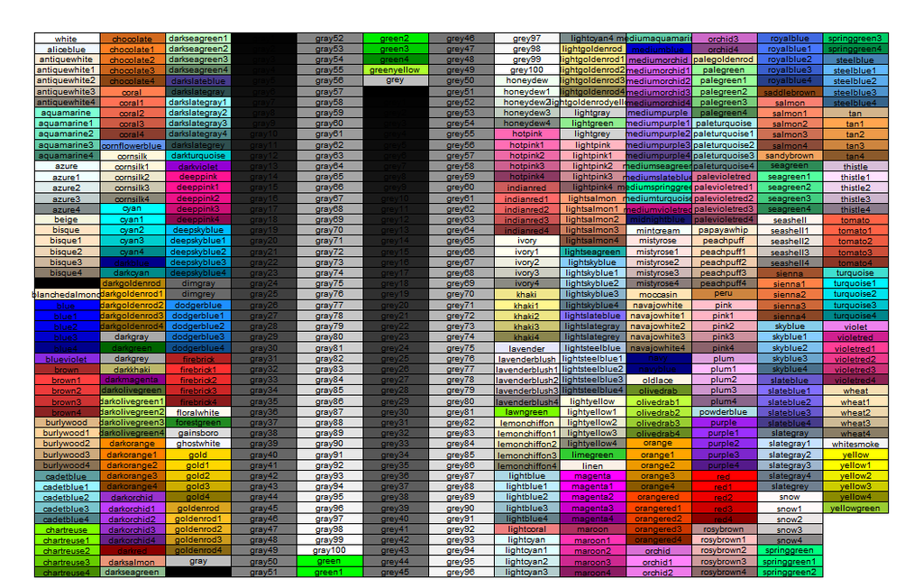

```r
liste = colors()

# dimensions de la grille des couleurs
nbcol = 13
nbrow = ceiling(length(liste) / nbcol)

# fonction qui construit le kieme rectangle de la grille
# (grille construite de haut en bas, de la 1ere a la derniere colonne)
rectangle = function(k) {
  i = (k-1) %% nbrow + 1
  j = (k-1) %/% nbrow + 1
  rect(xleft = j,ybottom = nbrow-i,
       xright = j+1,ytop = nbrow-i+1,col = liste[k])
  text(x = j+0.5, y = nbrow-i+0.5, labels = liste[k], cex = 0.6)
}

# on reduit les marges
omi_old = par("omi"); mai_old = par("mai")
par(omi = c(0,0,0,0)); par(mai = c(0,0,0,0))

plot.new(); plot.window(xlim = c(1, nbcol+1), ylim = c(1,nbrow+1))

# on applique la fonction rectangle a chaque couleur de R base
{invisible(lapply(seq_along(liste), rectangle))

# on retablit les marges pour la suite du document
par(omi = omi_old); par(mai = mai_old)}
```

# Toutes les variantes de bleus

Avec les expressions regulieres on peut selectionner les couleurs qui contiennent “blue” dans leur nom.

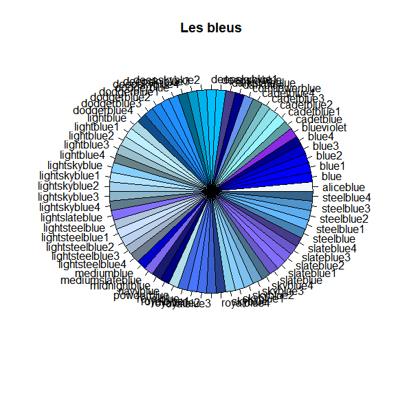

```r
teintes = grep("blue", colors(), value = TRUE)
pie(rep(1, length(teintes)), col = teintes, labels = teintes, main = "Les bleus")
```

# Addins

L’addin “Colour Picker” de Rstudio fournit une interface dynamique pour choisir dans la palette de couleurs standards ou pour definir la couleur de votre choix, cf https://deanattali.com/blog/colourpicker-package/.

# Arc-en-ciel et degrades de couleurs en R base

Les degrades de 2 ou 3 couleurs conviennent bien pour des valeurs numeriques (par exemple rouge pour des correlations negatives, bleu pour les positives et blanc pour les nulles).

Les palettes arc-en-ciel sont a reserver aux variables qualitatives, mais meme dans ce cas elles ne conviennent pas vraiment car elles peuvent donner une impression de proximite entre certaines modalites (par exemple les 3 bleus ci-dessous).

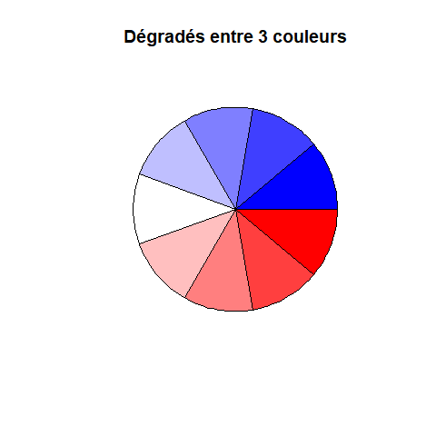

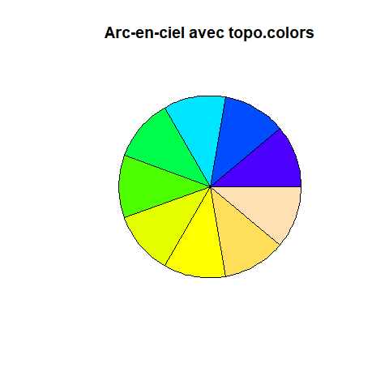

```r
ma_palette = colorRampPalette(c("blue", "white", "red"))(9)
{pie(rep(1,9), col = ma_palette, labels = "", main = "Dégradés entre 3 couleurs")
pie(rep(1,9), col = topo.colors(9), labels = "", main =  "Arc-en-ciel avec topo.colors")}
```

# Palettes du package RColorBrewer

Ce package propose des palettes de couleurs specifiques aux variables numeriques et aussi aux variables qualitatives, et on a la possibilite de filtrer les palettes de couleurs visibles par les daltoniens.

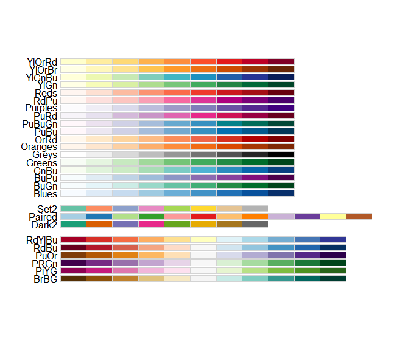

```r
library("RColorBrewer")
display.brewer.all(colorblindFriendly = TRUE)
```

### Palettes sequentielles : tons clairs >> sombres

A utiliser par exemple pour des variables numeriques a valeurs positives.

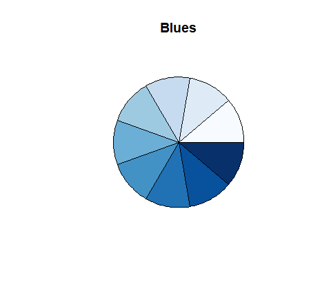

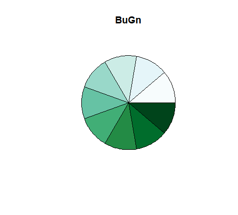

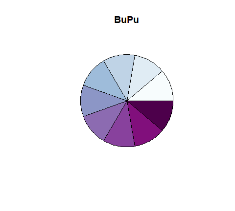

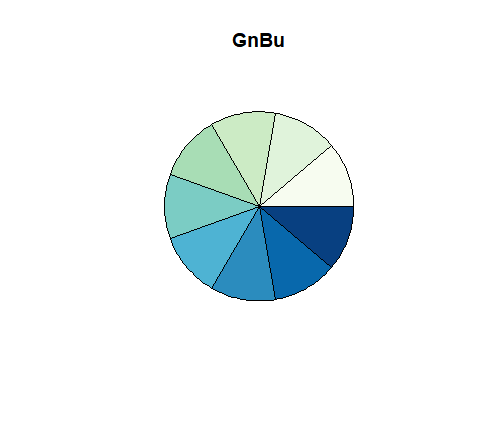

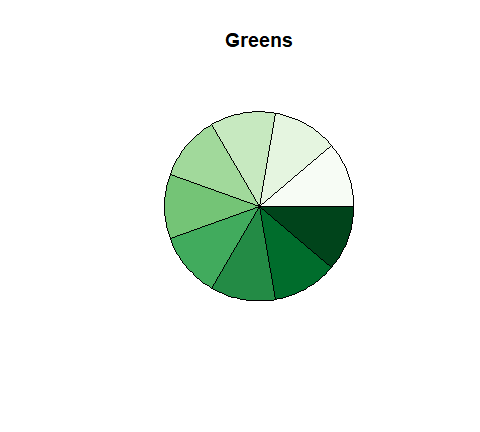

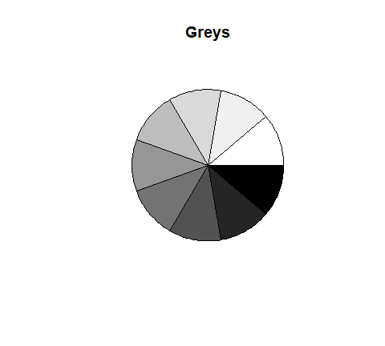

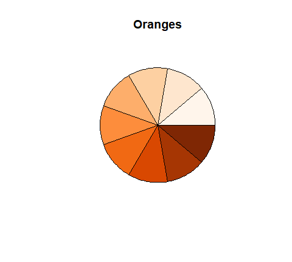

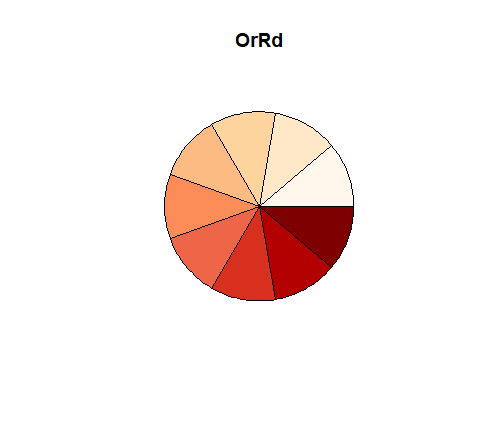

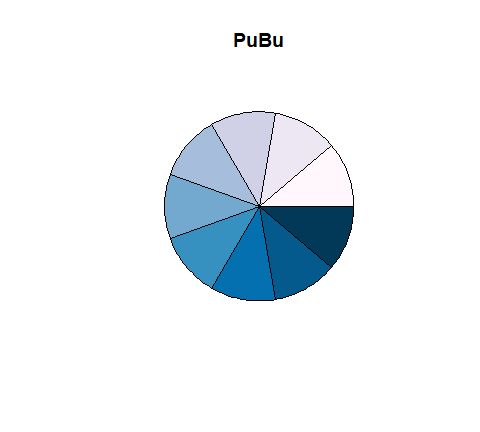

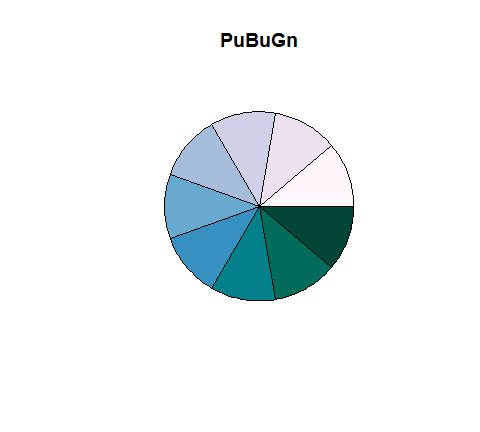

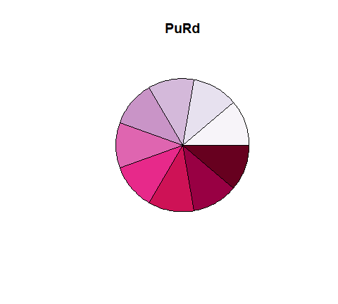

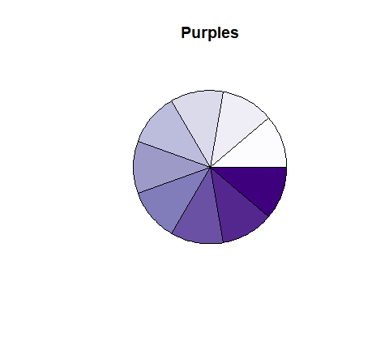

[6 more figures not shown]

```r
for (i in c("Blues", "BuGn", "BuPu", "GnBu", "Greens", "Greys", "Oranges", "OrRd", "PuBu",
            "PuBuGn", "PuRd", "Purples", "RdPu", "Reds", "YlGn", "YlGnBu", "YlOrBr", "YlOrRd")) {
  pie(rep(1,9), col = brewer.pal(9,i), labels = "", main = i)}
```

### Palettes divergentes : tons sombres >> clairs >> sombres

On peut les utiliser pour visualiser une matrice de correlations.

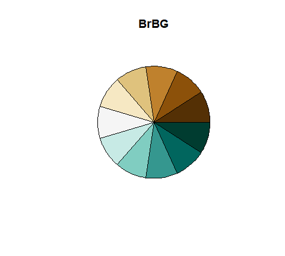

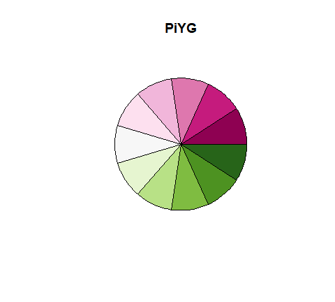

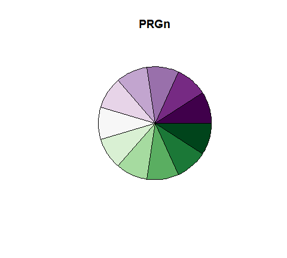

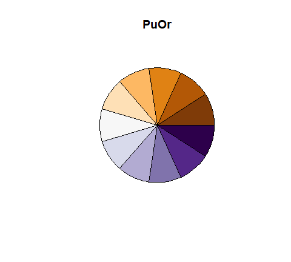

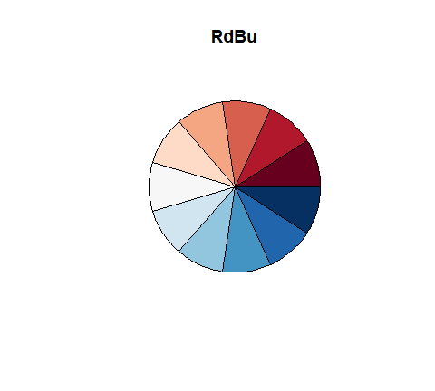

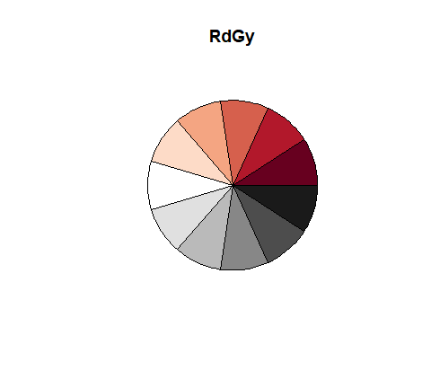

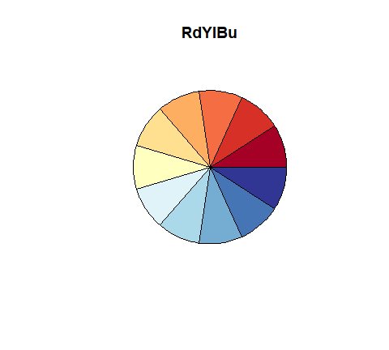

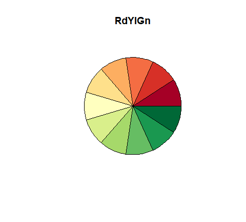

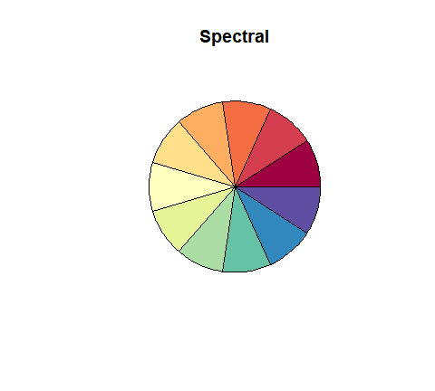

```r
for (i in c("BrBG", "PiYG", "PRGn", "PuOr", "RdBu", "RdGy", "RdYlBu", "RdYlGn", "Spectral")) {
  pie(rep(1,11), col = brewer.pal(11,i), labels = "", main = i)}
```

### Palettes qualitatives : contrastes entre couleurs successives

Palettes tres adaptees aux variables qualitatives avec au plus une dizaine de modalites.

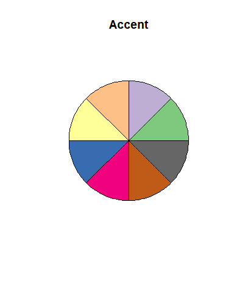

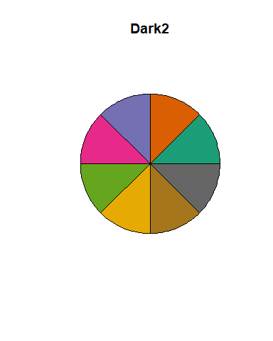

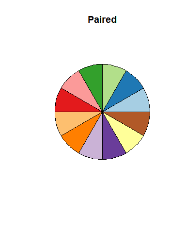

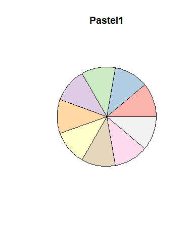

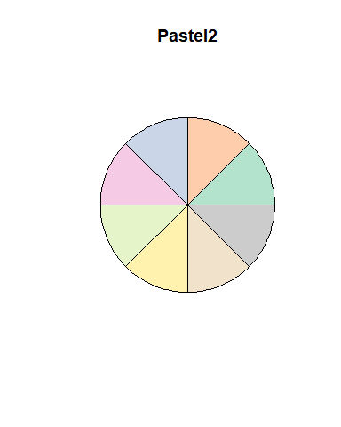

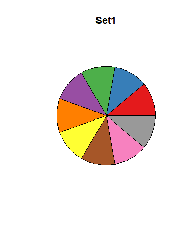

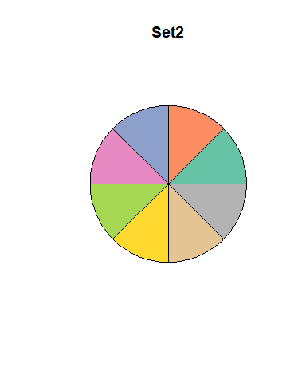

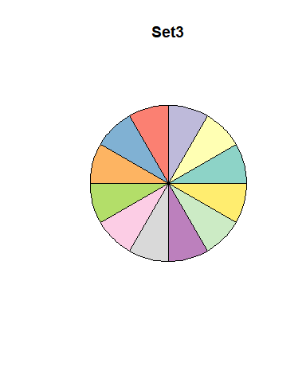

```r
m = c(8,8,12,9,8,9,8,12)
palettes = c("Accent", "Dark2", "Paired", "Pastel1", "Pastel2", "Set1", "Set2", "Set3")

for (i in 1:8) {
  pie(rep(1,m[i]),
      col = brewer.pal(m[i],palettes[i]), labels = "", main = palettes[i])}
```

# Palettes du package viridisLite

Quatre jolies palettes sequentielles concues a l’origine dans des bibliotheques Python https://matplotlib.org/stable/tutorials/colors/colormaps.html, leurs couleurs sont concues pour etre distinguees par les daltoniens et elles supportent bien une impression en noir et blanc. On peut voir ci-dessous ces palettes avec deuteranomalie (faible sensibilite au vert) et avec protanomalie (faible sensibilite au rouge).

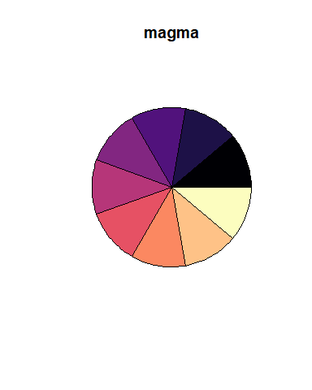

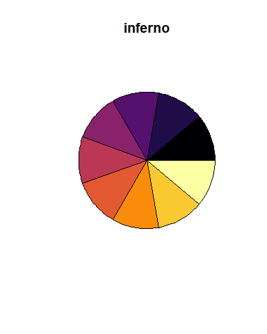

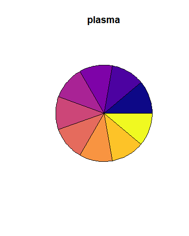

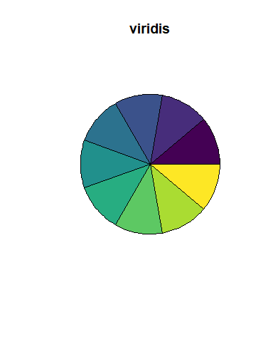

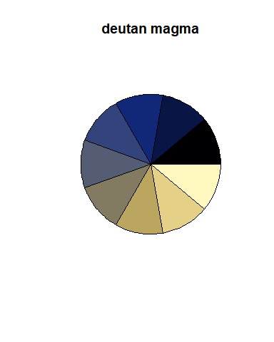

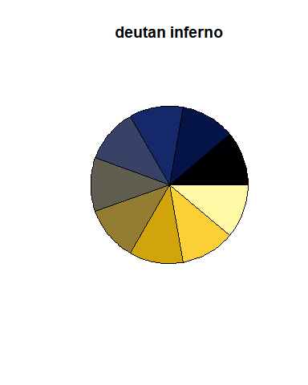

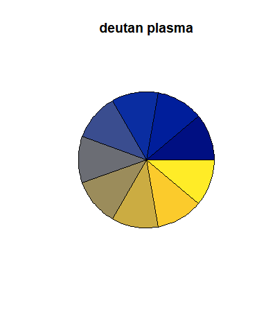

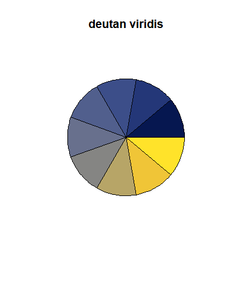

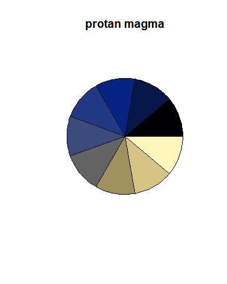

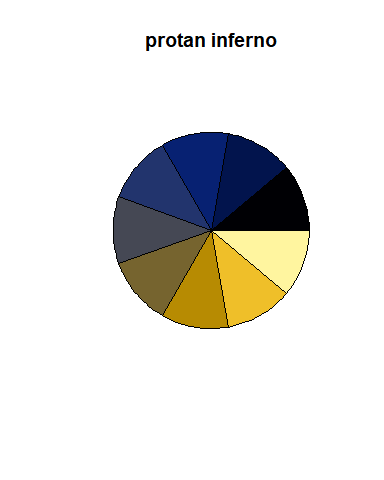

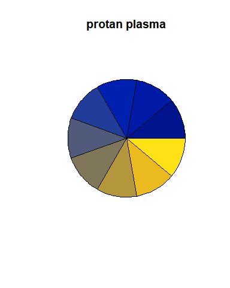

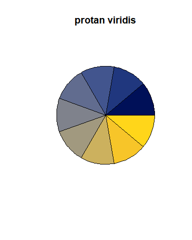

```r
library("viridisLite")

liste = list(magma = magma, inferno = inferno, plasma = plasma, viridis = viridis)
noms = names(liste)

for (j in 1:3) {
  noms0 = noms
  if (j == 2) noms0 = paste("deutan", noms)
  if (j == 3) noms0 = paste("protan", noms)
  vision = list(function(x) x,
                 colorspace::deutan,
                 colorspace::protan)
  for (i in 1:4) {
    pie(rep(1,9),
        col = vision[[j]](liste[[i]](9)),
        labels = "",
        main =  noms0[i]
      )
  }
}
```

# Quelques palettes du package khroma

Trois palettes respectivement qualitatives, divergentes et sequentielles.

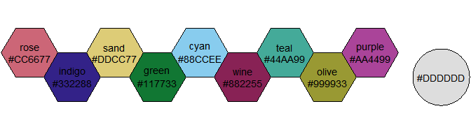

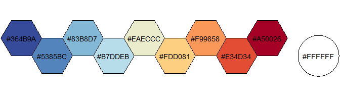

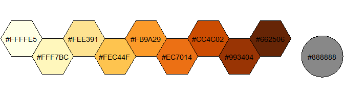

```r
library("khroma")
{plot_scheme(colour("muted")(9), colours = TRUE, names = TRUE, size = 0.9)
plot_scheme(colour("sunset")(9), colours = TRUE, size = 0.9)
plot_scheme(colour("YlOrBr")(9), colours = TRUE, size = 0.9)}
```

# Afficher une palette de couleurs avec une seule commande

Si vous n’aimez pas les diagrammes circulaires ou les grilles precedentes pour visualiser une palette de couleurs, ou que vous avez oublie le code pour les realiser, la fonction *show_col* du package *scales* sera votre amie :

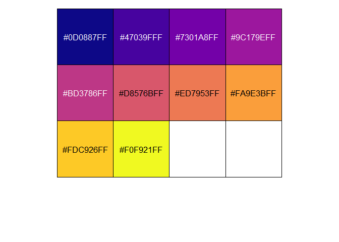

```r
scales::show_col(viridis::plasma(10))
```

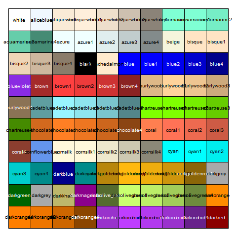

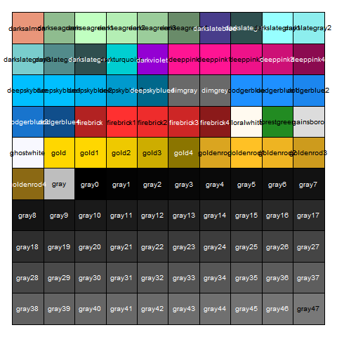

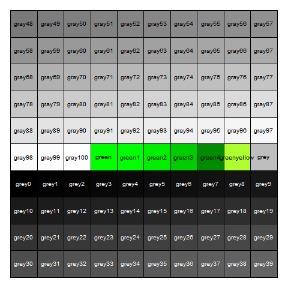

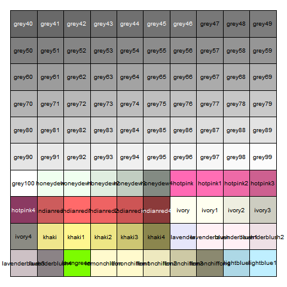

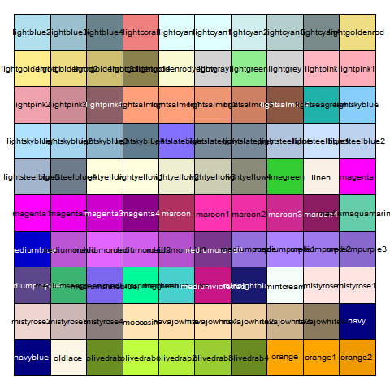

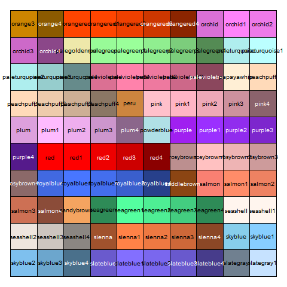

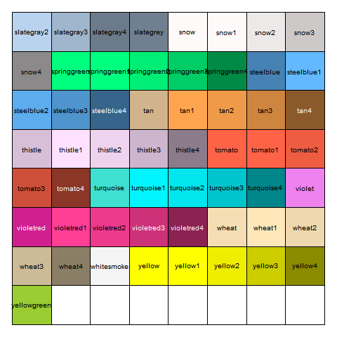

```r
cex = 0.6
scales::show_col(colors()[1:100], cex_label = cex)
scales::show_col(colors()[101:200], cex_label = cex)
scales::show_col(colors()[201:300], cex_label = cex)
scales::show_col(colors()[301:400], cex_label = cex)
scales::show_col(colors()[401:500], cex_label = cex)
scales::show_col(colors()[501:600], cex_label = cex)
scales::show_col(colors()[601:657], cex_label = cex)
```

**retour au debut du document**